# Through the eyes of the teacher - Multimodal exploration of expertise differences in the perception of classroom disruptions in a laboratory study

### Internal consistency (Omega) for Classroom Questionnaire

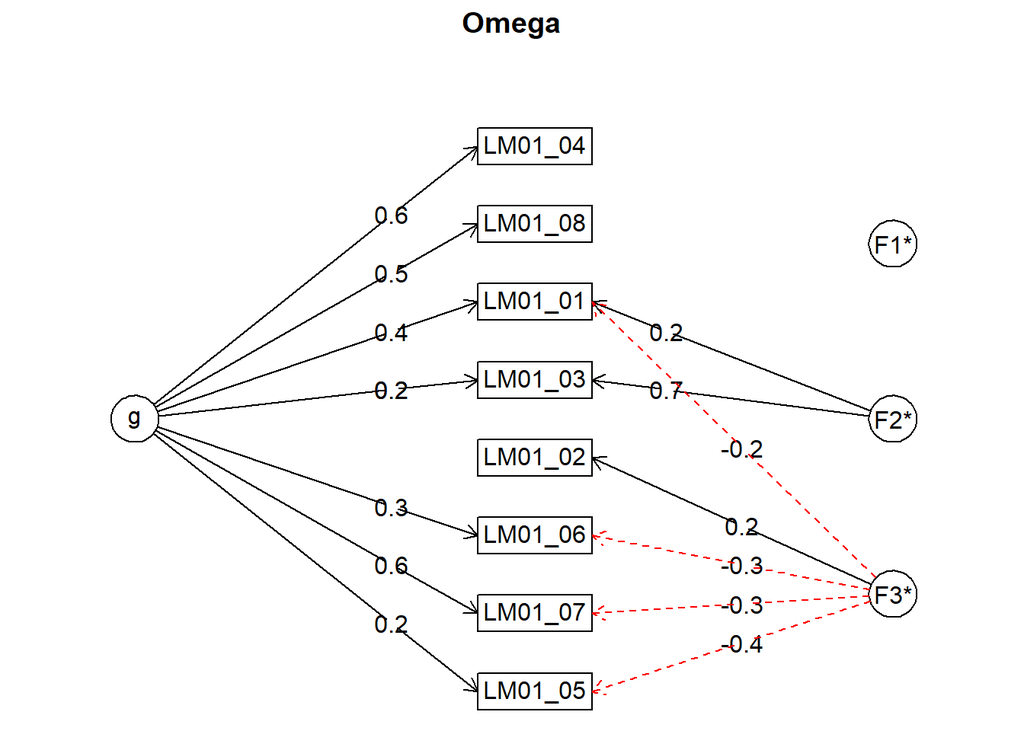

Omega Call: omegah(m = m, nfactors = nfactors, fm = fm, key = key, flip = flip, digits = digits, title = title, sl = sl, labels = labels, plot = plot, n.obs = n.obs, rotate = rotate, Phi = Phi, option = option, covar = covar) Alpha: 0.6 G.6: 0.6 Omega Hierarchical: 0.54 Omega H asymptotic: 0.79 Omega Total 0.68

Schmid Leiman Factor loadings greater than 0.2 g F1* F2* F3* h2 h2 u2 p2 com LM01_01 0.36 0.22 -0.22 0.23 0.23 0.77 0.56 2.43 LM01_02 0.22 0.11 0.89 0.26 2.78 LM01_03 0.23 0.74 0.61 0.61 0.39 0.09 1.20 LM01_04 0.65 0.43 0.43 0.57 0.98 1.03 LM01_05 0.25 -0.42 0.24 0.24 0.76 0.26 1.65 LM01_06 0.29 -0.29 0.18 0.82 0.47 2.29 LM01_07 0.58 -0.32 0.45 0.45 0.55 0.74 1.66 LM01_08 0.49 0.28 0.28 0.72 0.86 1.33

With Sums of squares of: g F1* F2* F3* h2 1.35 0.00 0.70 0.47 0.98

general/max 1.37 max/min = 2201.14 mean percent general = 0.53 with sd = 0.32 and cv of 0.6 Explained Common Variance of the general factor = 0.54

The degrees of freedom are 7 and the fit is 0.02 The number of observations was 84 with Chi Square = 1.64 with prob < 0.98 The root mean square of the residuals is 0.02 The df corrected root mean square of the residuals is 0.04 RMSEA index = 0 and the 10 % confidence intervals are 0 0 BIC = -29.38

Compare this with the adequacy of just a general factor and no group factors The degrees of freedom for just the general factor are 20 and the fit is 0.19 The number of observations was 84 with Chi Square = 15.17 with prob < 0.77 The root mean square of the residuals is 0.08 The df corrected root mean square of the residuals is 0.09

RMSEA index = 0 and the 10 % confidence intervals are 0 0.067 BIC = -73.44

Measures of factor score adequacy  
g F1* F2* F3* Correlation of scores with factors 0.80 0.02 0.77 0.58 Multiple R square of scores with factors 0.64 0.00 0.60 0.33 Minimum correlation of factor score estimates 0.27 -1.00 0.19 -0.33

Total, General and Subset omega for each subset g F1* F2* F3* Omega total for total scores and subscales 0.68 NA 0.59 0.42 Omega general for total scores and subscales 0.54 NA 0.47 0.30 Omega group for total scores and subscales 0.08 NA 0.12 0.12

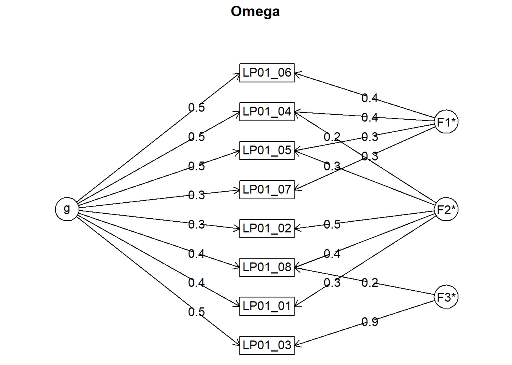

Omega Call: omegah(m = m, nfactors = nfactors, fm = fm, key = key, flip = flip, digits = digits, title = title, sl = sl, labels = labels, plot = plot, n.obs = n.obs, rotate = rotate, Phi = Phi, option = option, covar = covar) Alpha: 0.75 G.6: 0.75 Omega Hierarchical: 0.54 Omega H asymptotic: 0.66 Omega Total 0.81

Schmid Leiman Factor loadings greater than 0.2 g F1* F2* F3* h2 h2 u2 p2 com LP01_01 0.43 0.31 0.32 0.32 0.68 0.59 2.23 LP01_02 0.28 0.48 0.31 0.31 0.69 0.25 1.63 LP01_03 0.52 0.85 1.00 1.00 0.00 0.27 1.65 LP01_04 0.53 0.39 0.21 0.49 0.49 0.51 0.58 2.26 LP01_05 0.53 0.28 0.28 0.45 0.45 0.55 0.64 2.13 LP01_06 0.46 0.45 0.44 0.44 0.56 0.48 2.25 LP01_07 0.33 0.28 0.19 0.81 0.55 2.14 LP01_08 0.44 0.39 0.22 0.40 0.40 0.60 0.50 2.48

With Sums of squares of: g F1* F2* F3* h2 1.62 0.55 0.63 0.80 2.02

general/max 0.8 max/min = 3.67 mean percent general = 0.48 with sd = 0.15 and cv of 0.3 Explained Common Variance of the general factor = 0.45

The degrees of freedom are 7 and the fit is 0.09 The number of observations was 84 with Chi Square = 6.63 with prob < 0.47 The root mean square of the residuals is 0.04 The df corrected root mean square of the residuals is 0.07 RMSEA index = 0 and the 10 % confidence intervals are 0 0.131 BIC = -24.38

Compare this with the adequacy of just a general factor and no group factors The degrees of freedom for just the general factor are 20 and the fit is 0.37 The number of observations was 84 with Chi Square = 29.51 with prob < 0.078 The root mean square of the residuals is 0.11 The df corrected root mean square of the residuals is 0.13

RMSEA index = 0.074 and the 10 % confidence intervals are 0 0.13 BIC = -59.11

Measures of factor score adequacy  
g F1* F2* F3* Correlation of scores with factors 0.75 0.58 0.65 0.91 Multiple R square of scores with factors 0.56 0.33 0.42 0.84 Minimum correlation of factor score estimates 0.12 -0.34 -0.16 0.67

Total, General and Subset omega for each subset g F1* F2* F3* Omega total for total scores and subscales 0.81 0.68 0.57 1.00 Omega general for total scores and subscales 0.54 0.43 0.28 0.27 Omega group for total scores and subscales 0.18 0.25 0.29 0.73

## 3. Correlations